# ponpare_1

```python
import os.path
import matplotlib.pyplot as plt
import numpy as np
import seaborn as sns
import matplotlib.cm as cm
import pandas as pd
%matplotlib inline

user_list = pd.read_csv("user_list.csv")
user_list['REG_DATE'] = pd.to_datetime(user_list['REG_DATE'])
user_list['REG_MONTH'] = user_list['REG_DATE'].dt.month
user_list['REG_HOUR'] = user_list['REG_DATE'].dt.hour
```

## User statistics

```python
total_users = user_list['USER_ID_hash'].unique().shape[0]
print '*Total # of users: ', total_users
print '\n*Gender percentages:' # Gender percentages
f = user_list['USER_ID_hash'][user_list['SEX_ID']=='f'].unique().shape[0]
m = user_list['USER_ID_hash'][user_list['SEX_ID']=='m'].unique().shape[0]
print '% of female users: ', round(float(f)/(total_users),4)*100, '%'
print '% of male users: ', round(float(m)/(total_users),4)*100, '% \n'

print '*Registration status:'
users_withdrew = user_list[user_list['WITHDRAW_DATE'].isnull() == False]
users_active = user_list[user_list['WITHDRAW_DATE'].isnull()]
print '% of active users in the User list: ', round(float(users_active.shape[0])/total_users,4)*100, '%'
print '% of inactive users in the User list: ', round(float(users_withdrew.shape[0])/total_users,4)*100, '%\n'

print '*Among active users:'
active_f = users_active['USER_ID_hash'][user_list['SEX_ID']=='f'].shape[0]
active_m = users_active['USER_ID_hash'][user_list['SEX_ID']=='m'].shape[0]
print '% of active female users: ', round(float(active_f)/(users_active.shape[0]),4)*100, '%'
print '% of active male users: ', round(float(active_m)/(users_active.shape[0]),4)*100, '%'
print '\n*Among inactive users:'
inactive_f = users_withdrew['USER_ID_hash'][user_list['SEX_ID']=='f'].shape[0]
inactive_m = users_withdrew['USER_ID_hash'][user_list['SEX_ID']=='m'].shape[0]
print '% of inactive female users: ', round(float(inactive_f)/(users_withdrew.shape[0]),4)*100, '%'
print '% of inactive male users: ', round(float(inactive_m)/(users_withdrew.shape[0]),4)*100, '%'
```

```
*Total # of users:  22873

*Gender percentages:
% of female users:  48.02 %
% of male users:  51.98 %

*Registration status:
% of active users in the User list:  95.97 %
% of inactive users in the User list:  4.03 %

*Among active users:
% of active female users:  48.54 %
% of active male users:  51.46 %

*Among inactive users:
% of inactive female users:  35.57 %
% of inactive male users:  64.43 %
```

### User Age

Next, I look at a few other basic distribution of different user profiles. This is a distribution of users' ages. The single largest user group is between 35 and 40, if we use each bin size as 5.

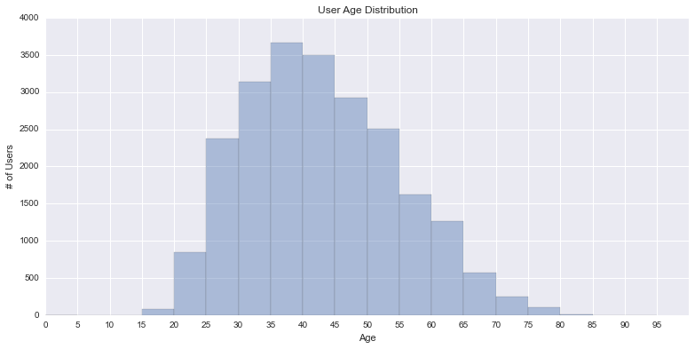

```python
plt.figure(figsize=(13,6))
sns.distplot(user_list['AGE'],bins = range(0,100,5),kde=False)
plt.xticks(np.arange(min(range(0,100,5)), max(range(0,100,5))+1, 5.0))
plt.xlabel('Age')
plt.ylabel('# of Users')
plt.title('User Age Distribution')
plt.show()
```

Just because I'm curious, I also look at user age distributions for inactive user groups and active user groups, to see if there are any differences. While the distributions look different, this could be attributable to the smaller size of the inactive user group (5% vs 95%).

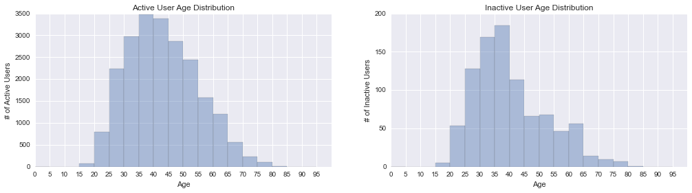

```python
plt.figure(figsize=(17,4))
plt.subplot(1, 2, 1)
sns.distplot(users_active['AGE'],bins = range(0,100,5),kde=False)
plt.xticks(np.arange(min(range(0,100,5)), max(range(0,100,5))+1, 5.0))
plt.xlabel('Age')
plt.ylabel('# of Active Users')
plt.title('Active User Age Distribution')

plt.subplot(1, 2, 2)
sns.distplot(users_withdrew['AGE'],bins = range(0,100,5),kde=False)
plt.xticks(np.arange(min(range(0,100,5)), max(range(0,100,5))+1, 5.0))
plt.xlabel('Age')
plt.ylabel('# of Inactive Users')
plt.title('Inactive User Age Distribution')
plt.show()
```

### User Registration

It would be interesting to also look at purchasing patterns of each group (active vs. inactive) to see if inactive users purchase differenly or something causes them to cancel their status. For now, I will continue looking at registration characteristics by user.

This histogram below shows that most users signed up in 2011 (60% of users). This makes wonder how this dataset was chosen, and if it was random, what led such a spike in 2011 and whether that would affect further purchasing behaviors.

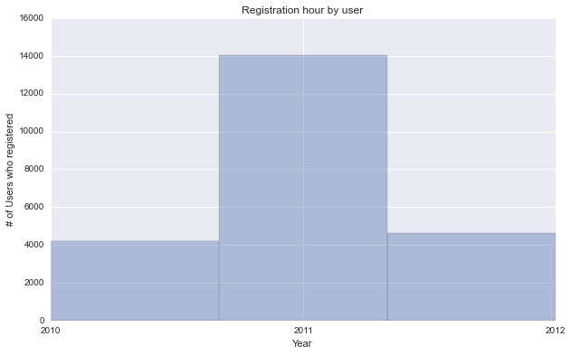

```python
plt.figure(figsize=(10,6))
sns.distplot(user_list['REG_DATE'].dt.year,bins=3, kde=False)
plt.ticklabel_format(useOffset=False)
plt.xticks(np.arange(min(user_list['REG_DATE'].dt.year), max(user_list['REG_DATE'].dt.year)+1, 1.0))
plt.xlabel('Year')
plt.ylabel('# of Users who registered')
plt.title('Registration hour by user')
plt.show()
```

The two histograms below shows what time of the year and what time of the day users are signing up for registration.

November and May show the highest percentage of user registration rate. Throughout the day, registration starts to go up in the morning and peaks at 5pm and again after 9pm. The histogram on the right has KDE(kernel density estimate) turned on, so the y-axis scale shows density, rather than number of users.

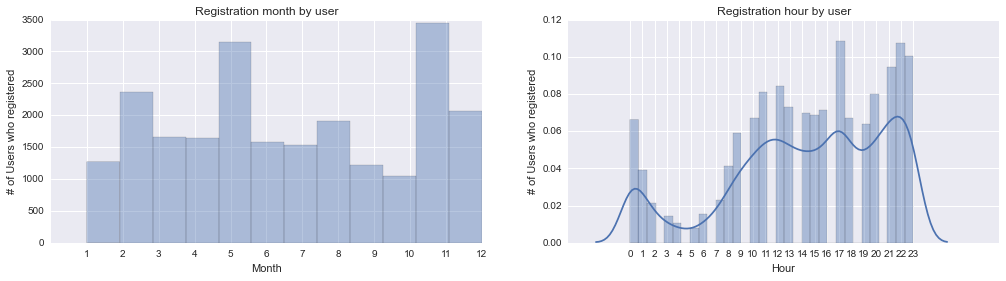

```python
plt.figure(figsize=(17,4))
#plot user registration by month
plt.subplot(1, 2, 1)
sns.distplot(user_list['REG_DATE'].dt.month,bins=12, kde=False)
plt.xlabel('Month')
plt.ylabel('# of Users who registered')
plt.title('Registration month by user')
plt.xticks(np.arange(min(user_list['REG_DATE'].dt.month), max(user_list['REG_DATE'].dt.month)+1, 1.0))

plt.subplot(1, 2, 2)
sns.distplot(user_list['REG_DATE'].dt.hour, kde=True)
plt.xlabel('Hour')
plt.ylabel('# of Users who registered')
plt.title('Registration hour by user')
plt.xticks(np.arange(min(user_list['REG_DATE'].dt.hour), max(user_list['REG_DATE'].dt.hour)+1, 1.0))
plt.show()
```

In looking at the below histogram by month and gender, there are no significant differences in gender for each month in registration. There seems to be the largest difference in December when there are more male users signing up than female users.

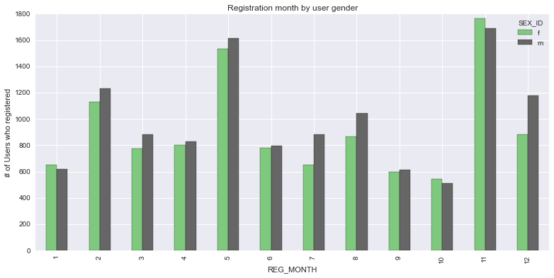

```python
#plot user registration by month and gender

age = user_list.groupby(['REG_MONTH','SEX_ID']).size().unstack()
age.plot(kind = 'bar', colormap = cm.Accent, figsize=(13,6))
plt.ylabel('# of Users who registered')
plt.title('Registration month by user gender')
plt.show()
```

There are only 5 hours where females register more than males which are mostly late mornings and early afternoons (10am to 1pm).

```
# of Hours(female > male):  5

Details of these 5 hours:
SEX_ID      f    m
REG_HOUR
1         311  309
10        548  518
11        658  637
12        708  639
13        592  568

# of Hours(male > female):  18
```

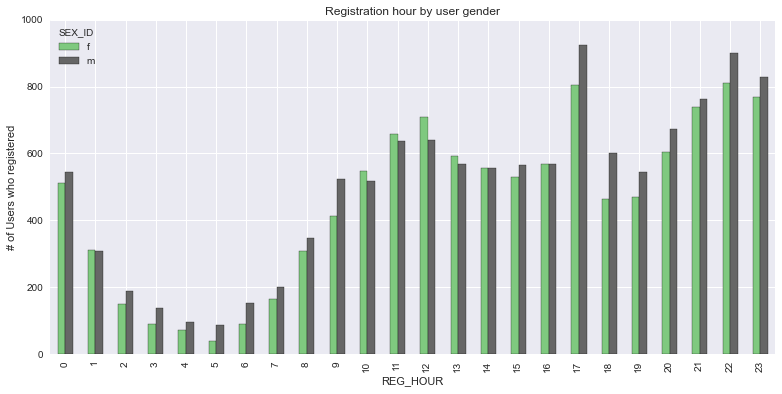

```python
hour = user_list.groupby(['REG_HOUR','SEX_ID']).size().unstack()
print '# of Hours(female > male): ', hour[hour['f']>hour['m']].shape[0]
print '\nDetails of these 5 hours:'
print hour[hour['f']>hour['m']]
print '\n# of Hours(male > female): ', hour[hour['m']>hour['f']].shape[0]
hour.plot(kind = 'bar', colormap = cm.Accent, figsize=(13,6) )
plt.ylabel('# of Users who registered')
plt.title('Registration hour by user gender')
plt.show()
```